# Autour du NPS : du texte au modèle de Kano

cb

19/10/2021

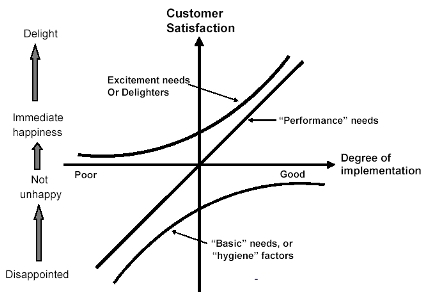

modèle de Kano

## Objectifs

Comprendre quels sont les facteurs qui sont associés à une faible ou une forte recommandation. Le cas est celui d’une chaine de jardinerie et d’une enquête menée sur sa clientèle dans les années 2010.

On utilise deux questions principalement :

- une échelle de recommandation (de 0 à 10)
- une question ouverte sur les raison de la note.

Sur la recommandation, c’est la technique du NPS qui est employée. On pourra lire la synthèse de [Daniel Ray](https://www.cairn.info/revue-l-expansion-management-review-2014-3-page-58.htm). On lira [ici](https://hbr.org/2003/12/the-one-number-you-need-to-grow) l’article original.

## les packages utilisés

On utilise principalement les ressources de `quanteda` et l’analyse factorielle des correspondances avec `Factominer`

```r
knitr::opts_chunk$set(echo = TRUE,include=TRUE, warning=FALSE, message=FALSE)
library(tidyverse)
library(lubridate)
library(quanteda)
library(quanteda.textplots)
library(quanteda.textstats)

library(ggwordcloud)
library(ggmosaic)
library(rcompanion)

library(cowplot)

library ("FactoMineR")
library(factoextra)

library(seededlda)

library(gam)


df<-read_csv("nps.csv", locale = locale(encoding = "WINDOWS-1252"))

#palette de couleur
col<-c("firebrick","Gold3","Darkgreen")
theme_set(theme_minimal())
```

## Distribution du NPS

Notre tableau de données rend compte de près de 14000 évaluations en terme de NPS de la relation à une enseigne de jardinage.

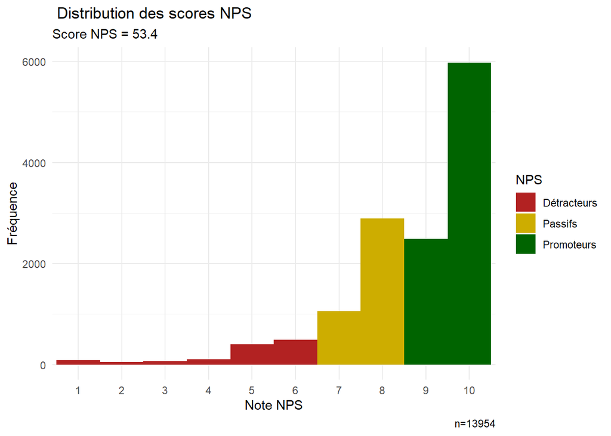

```r
foo1<-df %>%
  mutate(NPS=ifelse(nps<7, "Détracteurs",
                    ifelse(nps>6 & nps<9,"Passifs", "Promoteurs")),
         p=ifelse(NPS=="Promoteurs", 1, 0),
         d=ifelse(NPS=="Détracteurs", 1, 0))


#calcul du score NPS
d<- mean(foo1$d, na.rm=TRUE)
p<-mean(foo1$p, na.rm=TRUE)
score_nps<- round((p-d)*100,1)



g<-ggplot(foo1, aes(x=nps))+
  geom_histogram(binwidth = 1,aes(fill=NPS))+
  labs( title= " Distribution des scores NPS",
        subtitle = paste0("Score NPS = ", score_nps),
        caption = "n=13954",
        y = "Fréquence")+
  scale_fill_manual(values=col)+
  scale_x_discrete(name="Note NPS",
                   breaks=c("1","2","3","4","5","6","7", "8", "9", 10),
                   limits=c("1","2","3","4","5","6","7", "8", "9", 10))
g
```

```r
ggsave("NPS1.jpg", plot=last_plot(), width = 20, height = 20, units = "cm")
```

Comme nous allons traiter du texte et que celui n’est présent que dans une partie des réponses, on peut se demander s’il y a un biais.

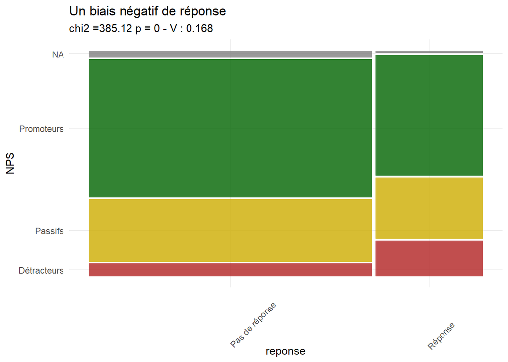

```r
#library(ggmosaic)
#library(rcompanion)
#recodons les répondants

foo1 <- foo1 %>%
  mutate(reponse=ifelse(is.na(explication), "Pas de réponse", "Réponse"))

t<-table(foo1$NPS,foo1$reponse)

chi2<-chisq.test(t)
chi<-round(chi2$statistic,2)
p<-round(chi2$p.value,3)
V<-cramerV(t, digit=3)

g1 <- ggplot(data = foo1) +
  geom_mosaic(aes(x=product(NPS ,reponse), fill = NPS))+
  theme(axis.text.x = element_text(angle = 45, hjust = -0.1, vjust = -0.2))+
  theme(legend.position = "none")+
  labs(title="Un biais négatif de réponse",
       subtitle=paste0("chi2 =",chi, " p = ", p, " - V : ", V))+
  scale_fill_manual(values=col)

g1
```

## Structure des corrélations

On peut examiner la corrélation de cet indicateurs à quelques autres variables : d’autres jugements, et les comportements antérieurs.

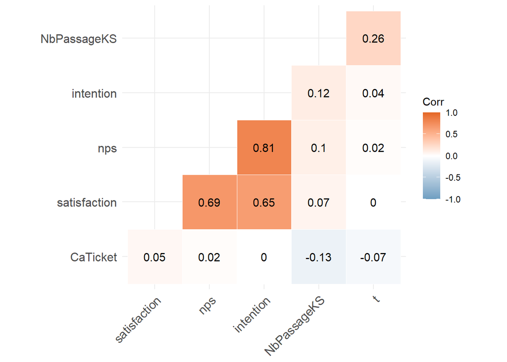

```r
foo2<-foo1 %>% select(3,4,5,7,8,9) %>% drop_na()
r<- round(cor(foo2),3)
library(ggcorrplot)
ggcorrplot(r, hc.order = TRUE, type = "lower",
   outline.col = "white",
   colors = c("#6D9EC1", "white", "#E46726"),
   lab=TRUE)
```

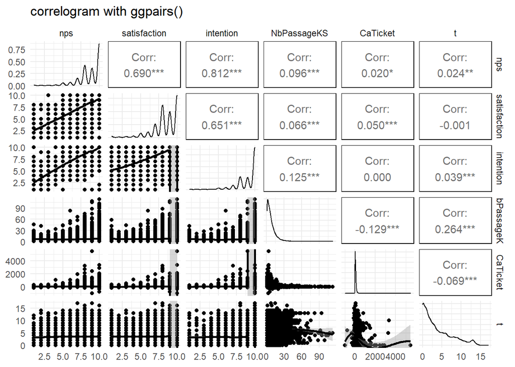

```r
library(GGally)
ggpairs(foo2, lower = list(continuous = "smooth_loess", combo = ggally_dot_no_facet),title="correlogram with ggpairs()")
```

## Un petit modèle linéaire

```r
#ggplot(foo1,aes(CaTicket))+geom_histogram(binwidth = 1)
#ggplot(foo1,aes(CaTicket, nps))+geom_point()+geom_smooth() +scale_x_log10()
#ggplot(foo1,aes(NbPassageKS, nps))+geom_point()+geom_smooth() +scale_x_log10()

#ggplot(foo1,aes(t, nps))+geom_point()+geom_smooth() +scale_x_log10()

foo1<- foo1%>%mutate(CaTicket=ifelse(CaTicket<0,0,CaTicket),
                     CaTicket_l=log10(CaTicket+1))

fit<- lm(nps~log(NbPassageKS)+log(CaTicket+1)+log(t+1), foo1)
summary(fit)
```

```
##
## Call:
## lm(formula = nps ~ log(NbPassageKS) + log(CaTicket + 1) + log(t +
##     1), data = foo1)
##
## Residuals:
##     Min      1Q  Median      3Q     Max
## -8.0501 -0.7427  0.3692  1.2375  1.9769
##
## Coefficients:
##                   Estimate Std. Error t value Pr(>|t|)
## (Intercept)        8.09391    0.06535 123.851  < 2e-16 ***
## log(NbPassageKS)   0.20481    0.01713  11.954  < 2e-16 ***
## log(CaTicket + 1)  0.07898    0.01322   5.975 2.35e-09 ***
## log(t + 1)        -0.03950    0.01799  -2.195   0.0282 *
## ---
## Signif. codes:  0 '***' 0.001 '**' 0.01 '*' 0.05 '.' 0.1 ' ' 1
##
## Residual standard error: 1.605 on 13590 degrees of freedom
##   (360 observations deleted due to missingness)
## Multiple R-squared:  0.0116, Adjusted R-squared:  0.01139
## F-statistic: 53.18 on 3 and 13590 DF,  p-value: < 2.2e-16
```

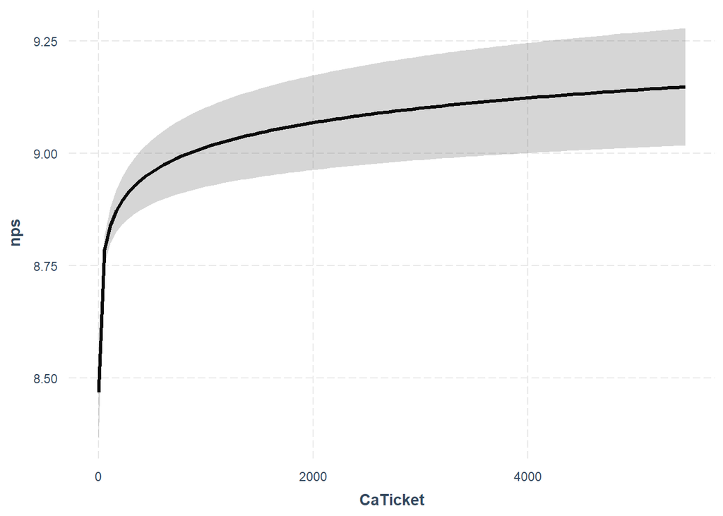

```r
library(jtools)
effect_plot(fit, pred=CaTicket, interval = TRUE)#scale_x_log10()
```

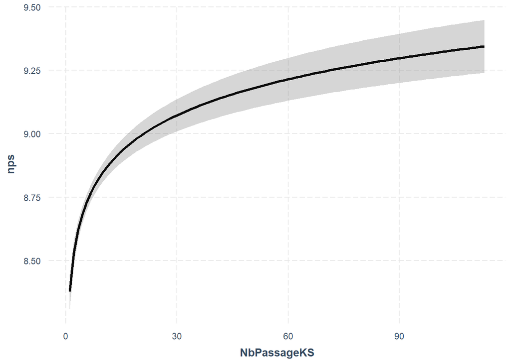

```r
effect_plot(fit, pred=NbPassageKS, interval = TRUE) #+scale_x_log10()
```

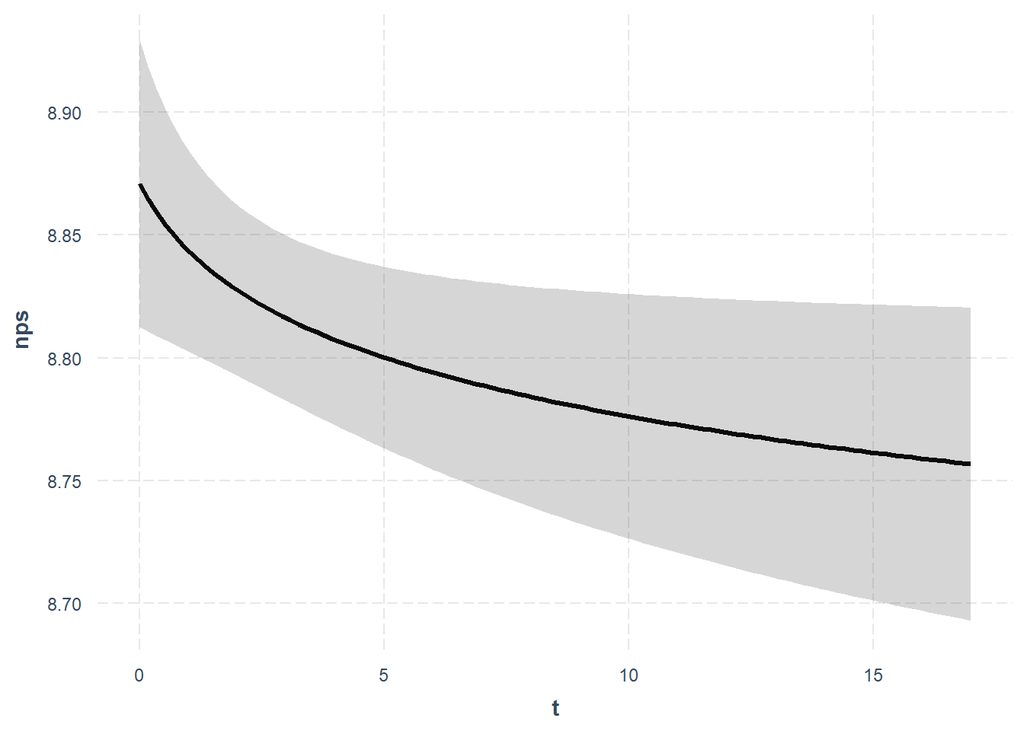

```r
effect_plot(fit, pred=t, interval = TRUE)#scale_x_log10()
```

## Corpus

On utilise quanteda .

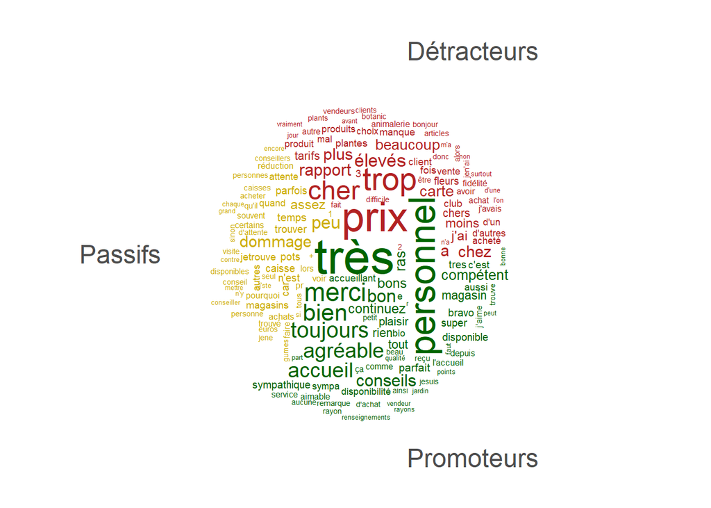

```r
# 1 définir le corpus

corpus<-corpus(foo1,text_field ="explication")

# 2 tokeniser le corpus

toks <- tokens(corpus, remove_punct = TRUE) %>%
    tokens_remove(pattern = stopwords("fr"))%>%
   tokens_remove(pattern="Botanic.*") %>%
    tokens_group(groups = NPS)

# 3 construire le dfm

dfm <- dfm(toks) %>%
  dfm_trim(min_termfreq = 40, verbose = FALSE)

# 4 afficher le wordcloud

textplot_wordcloud(dfm,comparison = TRUE, color = col)
```

```r
toks <- tokens(corpus, remove_punct = TRUE) %>%
    tokens_remove(pattern = stopwords("fr"))%>%
   tokens_remove(pattern="Botanic.*")
```

## Un autre wordcloud

Une autre méthode avec meilleure préparation du texte. et surtout de la collocation

pour le détail voir : https://quanteda.io/reference/textstat_collocations.html

```r
toks <- tokens(corpus, remove_punct = TRUE) %>%
  tokens_group(groups = NPS)

coloc <- textstat_collocations(toks, size = 2:4, min_count = 10) %>% filter(z>10)


head(coloc, 20)
```

```
##      collocation count count_nested length   lambda        z
## 1         un peu   262          262      2 5.348520 45.67674
## 2       les prix   239          239      2 3.460110 39.85398
## 3       la carte   157          157      2 4.669984 36.42423
## 4   le personnel   157          157      2 3.493441 34.16533
## 5           il y    87           87      2 5.251938 33.20647
## 6  bons conseils    69           69      2 5.940169 33.11318
## 7    bon accueil    74           74      2 5.785804 32.88838
## 8            y a    90           90      2 5.038816 32.35185
## 9      prix sont   118          118      2 3.602525 31.94199
## 10     en caisse   104          104      2 4.404127 31.53996
## 11 votre magasin    86           86      2 4.293482 30.07066
## 12    du magasin   105          105      2 3.494184 29.71740
## 13     chez vous    62           62      2 4.991237 29.62499
## 14 personnel est    98           98      2 3.527588 29.08215
## 15   aux caisses    48           48      2 6.149972 28.49342
## 16 très agréable    86           86      2 4.177950 28.49024
## 17     pas assez    96           96      2 4.716878 28.35137
## 18     trop cher    58           58      2 4.604763 27.65177
## 19     très bien    94           94      2 3.408625 27.35743
## 20  chez botanic    49           49      2 4.873511 26.91241
```

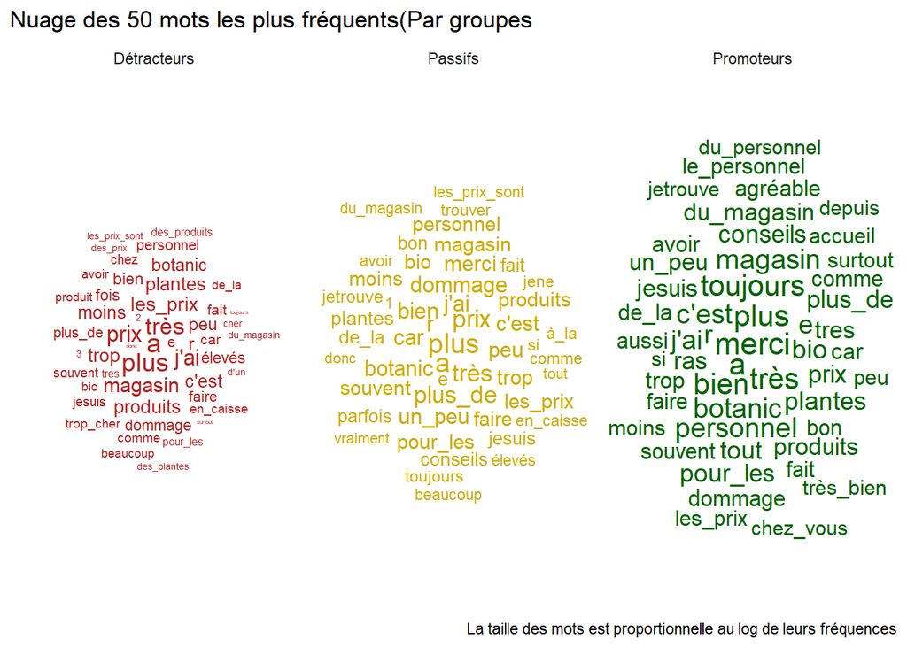

```r
toks2 <- tokens_compound(toks, pattern = coloc) %>%
  tokens_remove(pattern = stopwords("fr") )



dfm <-toks2 %>%
    tokens_group(groups = NPS)%>%
  dfm()

stat<- dfm %>%
  textstat_frequency(n = 50,  groups = NPS)

g_b<-ggplot(stat, aes(label = feature)) +
  geom_text_wordcloud(aes(size=log(frequency), color=group)) +
  theme_minimal()+
  facet_wrap(vars(group))+
  scale_color_manual(values=col)+
  labs(title="Nuage des 50 mots les plus fréquents(Par groupes",
       caption = "La taille des mots est proportionnelle au log de leurs fréquences")
g_b
```

```r
ggsave("NPS3.jpg", plot=last_plot(), width = 20, height = 20, units = "cm")
```

## Pour comparer les segments, le Keyness index est particulièrement utile

Il est calculé en comparant un groupe cible à l’ensemble des autres groupes par une mesure d’association : un chi², ou un point.wise correlation.

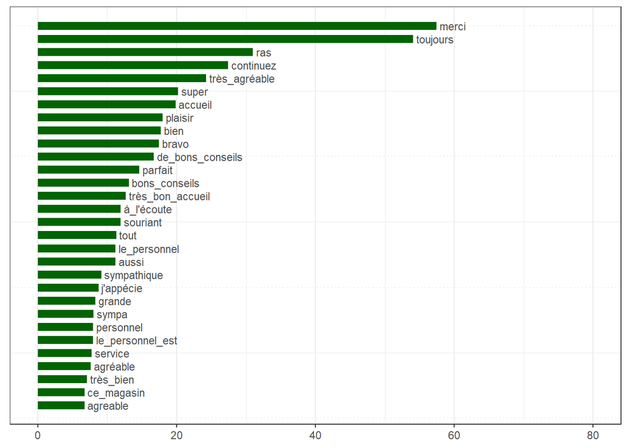

```r
# Create a dfm per group
dfm <-toks2 %>%
    tokens_group(groups = NPS) %>%
  dfm()


# Calculate keyness and determine "Promoteurs" as target group againts all other categories
result_keyness <- textstat_keyness(dfm, target = "Promoteurs") %>% filter (n_target>20)

# Plot estimated word keyness
g1<-textplot_keyness(result_keyness,   n = 30L, labelsize = 3,   show_legend = FALSE,
                     show_reference = FALSE,   color = c("Darkgreen", "gray"))+
  xlim(0,80) +
  labs(x=NULL)

g1
```

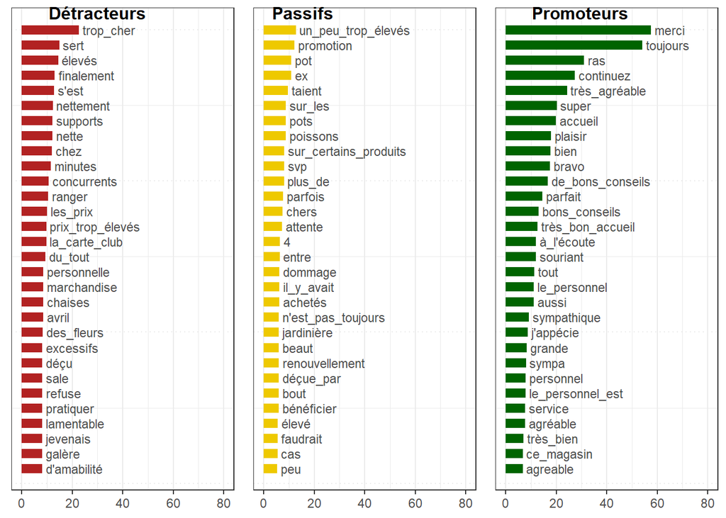

```r
result_keyness <- textstat_keyness(dfm, target = "Détracteurs" )
g2<-textplot_keyness(result_keyness,   n = 30L, labelsize = 3,   show_legend = FALSE,
                     show_reference = FALSE,   color = c("firebrick", "gray"))+
  xlim(0,80)+
  labs(x=NULL)


result_keyness <- textstat_keyness(dfm, target = "Passifs")
g3<-textplot_keyness(result_keyness,   n = 30L, labelsize = 3,   show_legend = FALSE,   show_reference = FALSE,    color = c("gold2", "gray"))+xlim(0,80)+ labs(x=NULL)



p<- plot_grid(g2, g3 ,g1,  labels = c('Détracteurs', 'Passifs', 'Promoteurs'), label_size = 12, ncol=3)

p
```

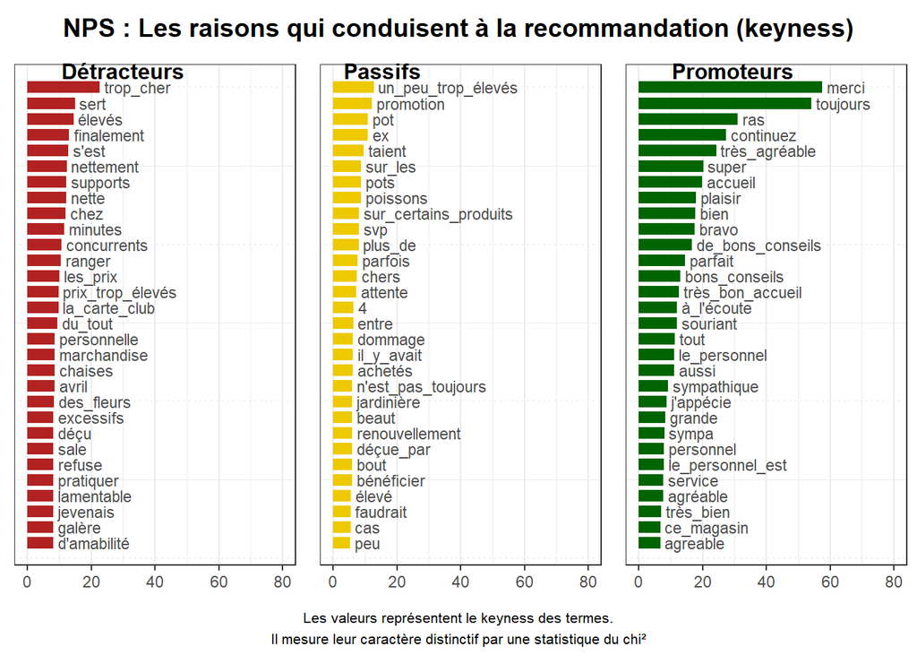

```r
title <- ggdraw() + draw_label("NPS : Les raisons qui conduisent à la recommandation (keyness)", fontface='bold')
note <- ggdraw()+ draw_text("Les valeurs représentent le keyness des termes.\nIl mesure leur caractère distinctif par une statistique du chi²", size=8,x = 0.5, y = 0.5)


plot_grid(title, p,note, ncol=1, rel_heights=c(0.1, 1)) # rel_heights values control title margins
```

```r
ggsave("NPS4.jpg", plot=last_plot(), width = 20, height = 20, units = "cm")
#  pour une comparaison deux à deux
#   pres_corpus <- corpus_subset(corpus, NPS %in% c("Détracteurs", "Promoteurs"))


#plot_grid(g ,p,d, labels = c("", "", "", ""), label_size = 12, ncol = 2, nrow = )

#ggsave("NPS5.jpg", plot=last_plot(), width = 20, height = 20, units = "cm")
```

## Un peu de topic analysis

La structure du modèle

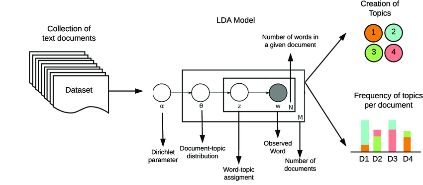

“modèle LDA”

source : https://arxiv.org/pdf/1003.0783.pdf

preparation des données

```r
# pre processing :
foo1<- foo1 %>%
  filter(!is.na(explication))
corpus<-corpus(foo1,text_field ="explication")

toks <- tokens(corpus, remove_punct = TRUE)

cols <- textstat_collocations(toks, size = 2:4, min_count = 10) %>% filter(z>15)

toks2 <- tokens_compound(toks, pattern = cols) %>%
  tokens_remove(pattern = stopwords("fr") )

dfm<-dfm(toks2)
```

estimation du modèle

```r
#library(seededlda)
set.seed(123)
tmod_lda <- textmodel_lda(dfm, k = 7)
#lister les mots les plus associés
terms(tmod_lda, 25)
dfm$topic <- topics(tmod_lda)

saveRDS(tmod_lda,"lda.rds")

saveRDS(topic,"topic.rds")
```

On sauvegarde les résultats pour se prémunir de l’instabilité des solutions ( en dépit du set seed) dans un format rds

## Une bonne vieille analyse des correspondances pour associer les segments aux thèmes du discours

pour plus de détails sur l’analyse des correspondances regarder par exemple [Anne B Dufour](https://pbil.univ-lyon1.fr/R/pdf/add2.pdf).

```r
dfm<-readRDS("topic.rds")
#un peu de recodage
table(dfm$topic)
```

```
##
## topic1 topic2 topic3 topic4 topic5 topic6 topic7
##    479    417    543    832    483    415    668
```

```r
#on recode pour une meilleure lecture
dfm$topic2[dfm$topic=="topic1"]<-"Caisse"
dfm$topic2[dfm$topic=="topic2"]<-"Magasin"
dfm$topic2[dfm$topic=="topic3"]<-"bioplantes"
dfm$topic2[dfm$topic=="topic4"]<-"Personnel"
dfm$topic2[dfm$topic=="topic5"]<-"Cartedefid"
dfm$topic2[dfm$topic=="topic6"]<-"Achat"
dfm$topic2[dfm$topic=="topic7"]<-"prix"

table(dfm$topic2)
```

```
##
##      Achat bioplantes     Caisse Cartedefid    Magasin  Personnel       prix
##        415        543        479        483        417        832        668
```

```r
#le tableau croisé

ca<- table(dfm$topic2, dfm$NPS)
prop.table(ca, 2)
```

```
##
##              Détracteurs    Passifs Promoteurs
##   Achat       0.15273312 0.11996251 0.08858361
##   bioplantes  0.11254019 0.17150890 0.13548081
##   Caisse      0.13987138 0.14807873 0.10658456
##   Cartedefid  0.16559486 0.14620431 0.10326859
##   Magasin     0.07877814 0.09465792 0.12316438
##   Personnel   0.05787781 0.09653233 0.32638560
##   prix        0.29260450 0.22305530 0.11653245
```

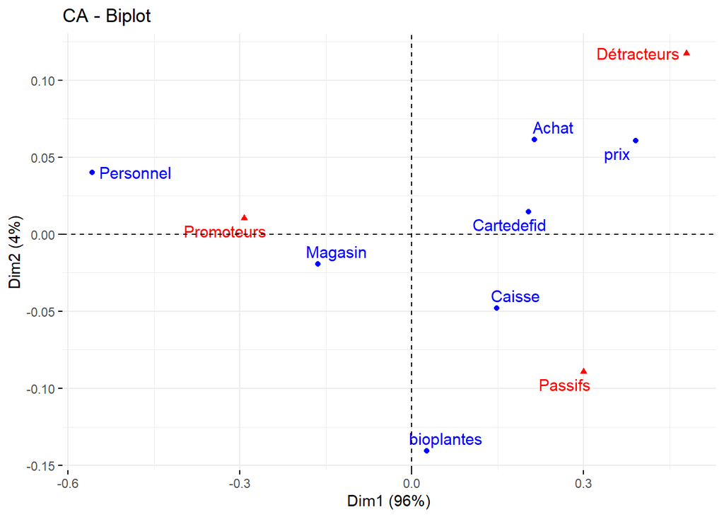

```r
#library ("FactoMineR")
#library(factoextra)
res.ca <- CA (ca, graph = FALSE)
fviz_ca_biplot (res.ca, repel = TRUE)
```

## Régression gam pour mesurer les non-linéarités

elles sont non linéaires donc adaptées à détecter une structure type kano (pour certais attributs l’absence conduit à l’insatisfaction, mais leur présence ne conduit pas à plus d’information, et pour d’autres leur absence ne conduit pas à l’insatisfaction alors que leur présence renforce la satisfaction)

Dans l’idée celà correspond à la théorie bifactorielle de herzberg.

inspiré de https://rpubs.com/apierucci/lm-gam

```r
tmod_lda<- readRDS("lda.rds")
theta<-tmod_lda$theta
topic<-cbind(foo1,theta)

#on recode pour une meilleure lecture
topic <- topic %>%
  rename(
Caisse = topic1,
Magasin = topic2,
Bioplantes= topic3,
Personnel=topic4,
Cartedefid= topic5,
Achat= topic6,
Prix =topic7)


library(gam)

mod1 <- gam(nps ~ s(Caisse) +s(Bioplantes)+s(Cartedefid)+s(Magasin)+s(Personnel)+s(Prix),
data = topic, family = gaussian)

summary(mod1)
```

```
##
## Call: gam(formula = nps ~ s(Caisse) + s(Bioplantes) + s(Cartedefid) +
##     s(Magasin) + s(Personnel) + s(Prix), family = gaussian, data = topic)
## Deviance Residuals:
##     Min      1Q  Median      3Q     Max
## -8.6663 -0.7370  0.3912  1.3421  3.0125
##
## (Dispersion Parameter for gaussian family taken to be 3.5739)
##
##     Null Deviance: 15277.08 on 3801 degrees of freedom
## Residual Deviance: 13498.76 on 3777 degrees of freedom
## AIC: 15659.01
## 37 observations deleted due to missingness
##
## Number of Local Scoring Iterations: NA
##
## Anova for Parametric Effects
##                 Df  Sum Sq Mean Sq  F value    Pr(>F)
## s(Caisse)        1    31.1   31.09   8.6977  0.003206 **
## s(Bioplantes)    1     6.9    6.92   1.9357  0.164220
## s(Cartedefid)    1   134.8  134.76  37.7063 9.074e-10 ***
## s(Magasin)       1    21.2   21.23   5.9412  0.014837 *
## s(Personnel)     1  1278.7 1278.73 357.7934 < 2.2e-16 ***
## s(Prix)          1    19.0   18.95   5.3034  0.021338 *
## Residuals     3777 13498.8    3.57
## ---
## Signif. codes:  0 '***' 0.001 '**' 0.01 '*' 0.05 '.' 0.1 ' ' 1
##
## Anova for Nonparametric Effects
##               Npar Df Npar F     Pr(F)
## (Intercept)
## s(Caisse)           3 2.4614   0.06077 .
## s(Bioplantes)       3 2.6208   0.04910 *
## s(Cartedefid)       3 0.7900   0.49936
## s(Magasin)          3 3.2169   0.02189 *
## s(Personnel)        3 2.9134   0.03308 *
## s(Prix)             3 8.0422 2.435e-05 ***
## ---
## Signif. codes:  0 '***' 0.001 '**' 0.01 '*' 0.05 '.' 0.1 ' ' 1
```

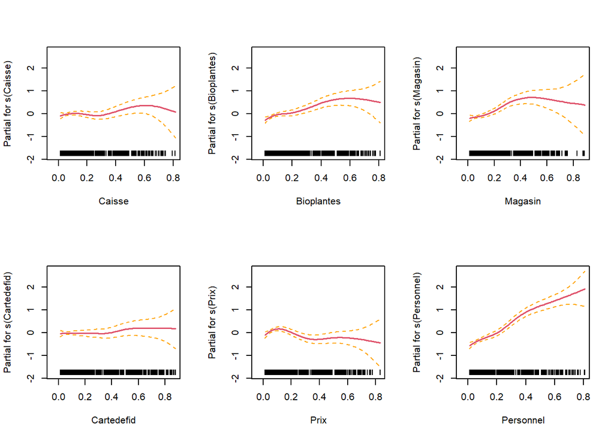

```r
par(mfrow = c(2, 3))

termplot(mod1,rug = TRUE, se = TRUE,  terms = c("s(Caisse)", "s(Bioplantes)", "s(Magasin)", "s(Cartedefid)", "s(Prix)", "s(Personnel)"))
```